# Analiza tržišta aparata za kavu

Konkurenti: De`Longhi, LatteGo, Krups, Nespresso

## **Medijski prostor**

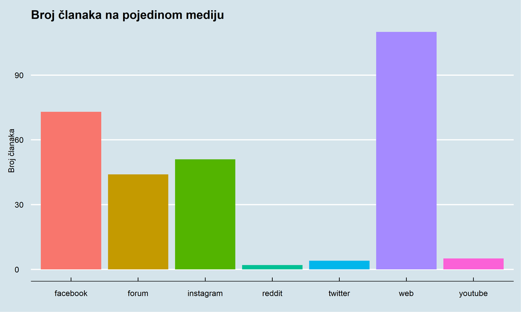

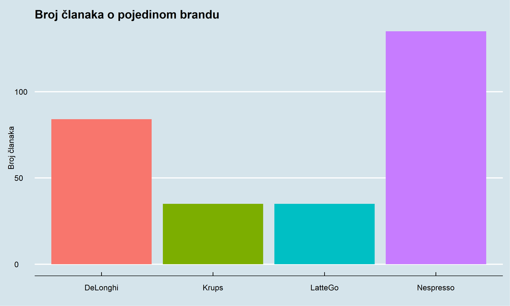

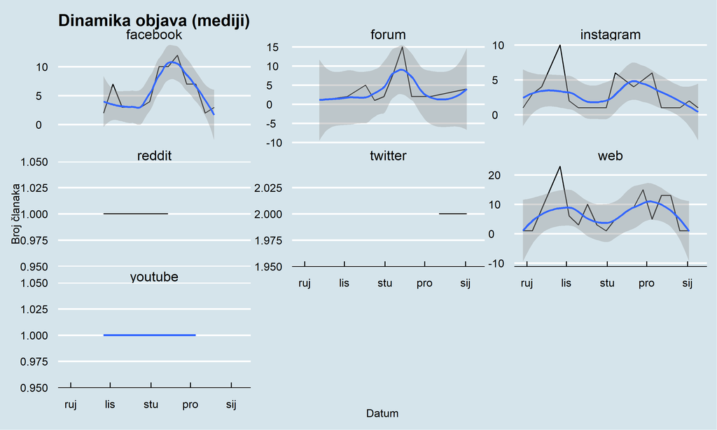

[figure not shown]

- Najčešće riječi su nazivi brandova (Nespresso,DeLonghi i LatteGo)
- Često se spominju i riječi *dom, namještaj, akcije i veliki saloni namještaja*
- Ovo ukazuje na *važnost “mitologije doma”* (manja važnost “mitologije okusa” i/ili “mitologije stila”)
- Od prosinca zaoštrena konkurencija između Nespresso, LatteGo i Krups

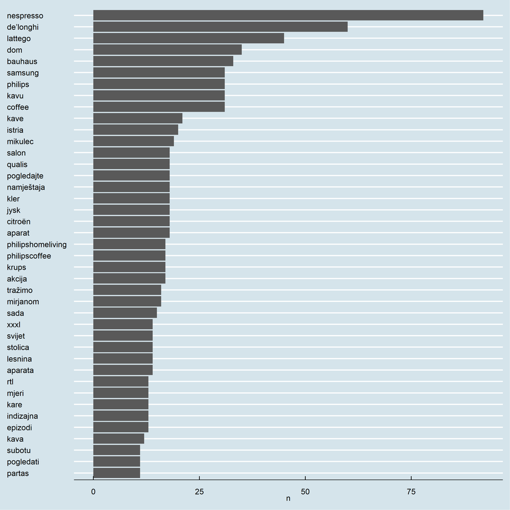

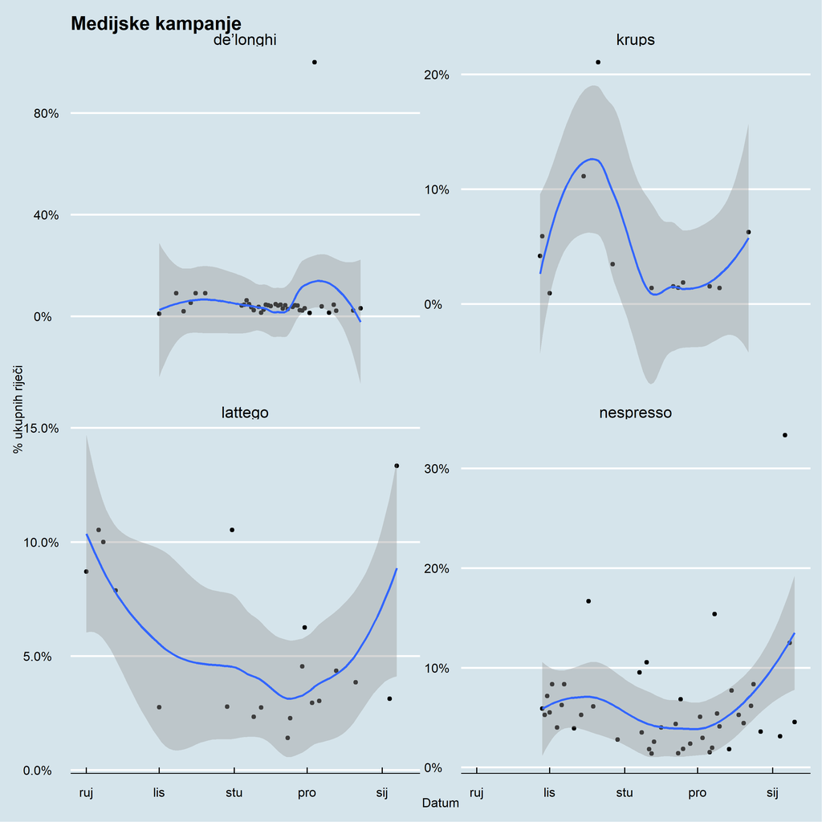

- Općenito **pozitivan sentiment** medijskih objava
- Pozitivan sentiment na osnovi tematike vezane uz **dom, obitelj i kvalitetu života**

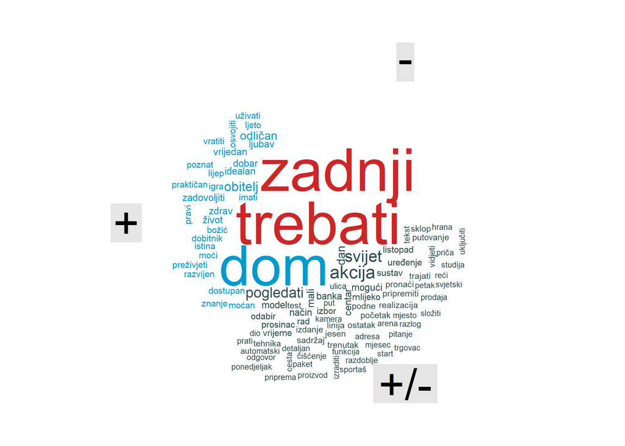

## **Analiza sentimenta**

- Pozitivan sentiment u periodu pred i za vrijeme blagdana
- Razdoblje za plasman proizvoda na tržište kada je dom u fokusu

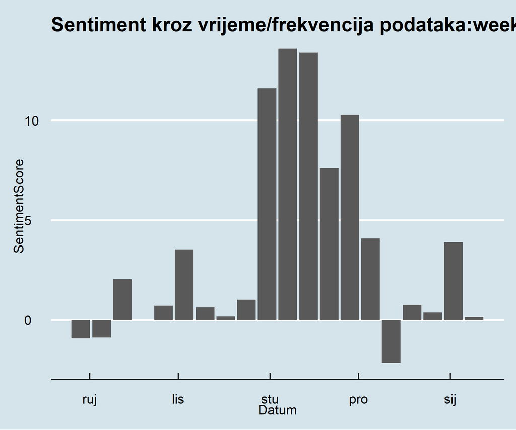

- Riječi koje najviše doprinose pozitivnom sentimentu vezane uz **dom**, zdravlje i kvalitetu života
- Važnost nagradnih igara i darivanja

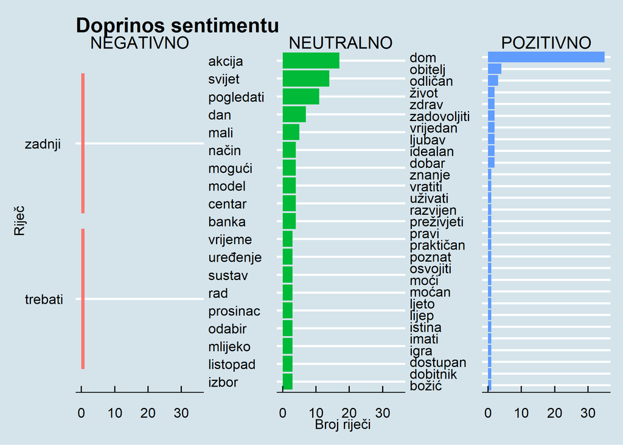

- Najbolje plasirane medijske objave ima DeLongi (najveći indeks pozitivnosti)
- Dobra medijska strategija;znatno bolja pozicija od tržišnog lidera Nespresso
- Tržišni lider Nespresso, LatteGo i Krups slični

| kword | pozWords | word | pozitivnostIndex |
| --- | --- | --- | --- |
| DeLonghi | 41 | 1196 | 3.428094 |
| Nespresso | 20 | 1083 | 1.846722 |
| LatteGo | 10 | 546 | 1.831502 |
| Krups | 4 | 233 | 1.716738 |

## **Najvažniji pojmovi**

- Najbitnije riječi izračunate pomoću [IDF (inverse document frequency)](https://citeseerx.ist.psu.edu/viewdoc/download?doi=10.1.1.438.2284&rep=rep1&type=pdf) metode
- Vidljiv **fokus DeLonghija na dom**, salone namještaja i općenito tematiku doma (saloni namještaja)
- **Krups pozicioniran u domenu bijele tehnike** (saloni bijele tehnike)
- **LatteGo jako ističe okus, kvalitetu i tehnologiju** (prepoznatljivost u okviru branda Phillips)
- **Nespresso gradi brand na okusu i stilu življenja** (socijalizacija i kultura pijenja kave)

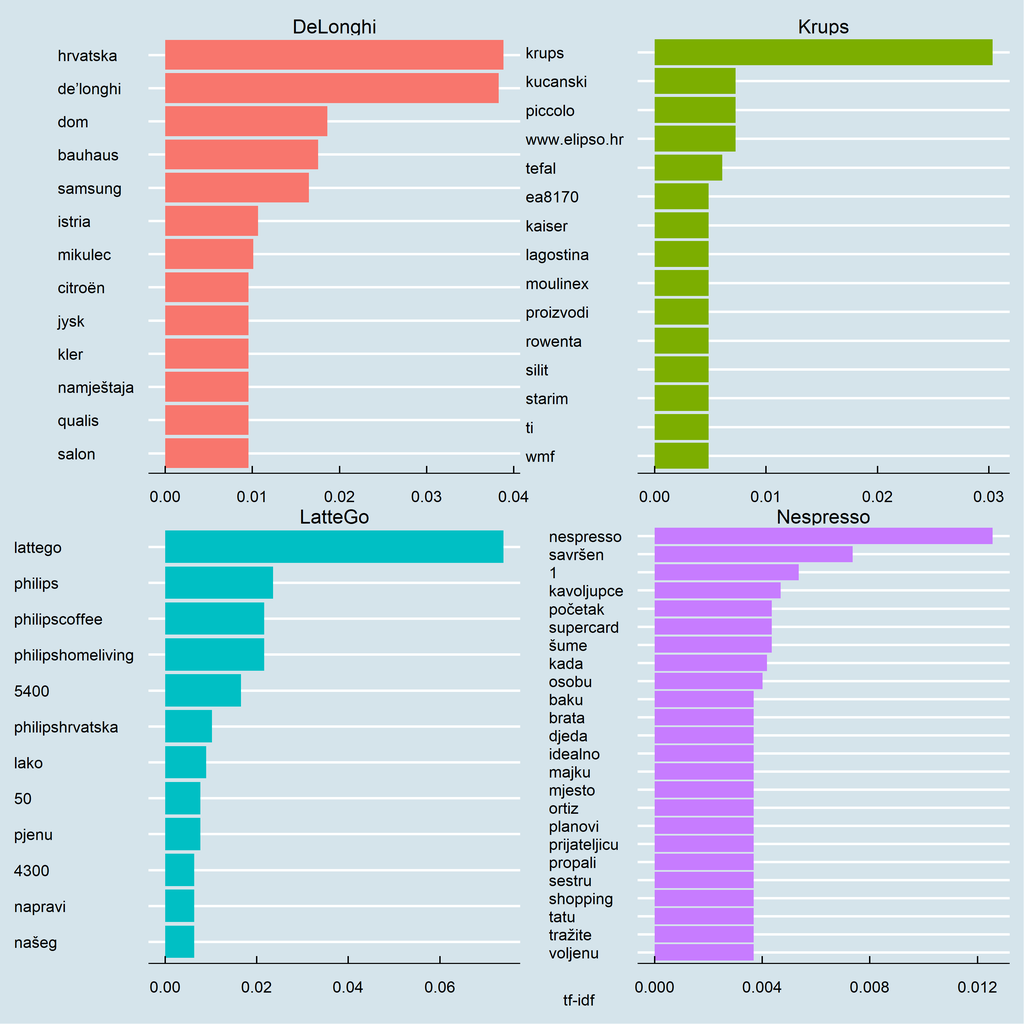

- Jednaki zaključci na osnovi fraza (bigrami)

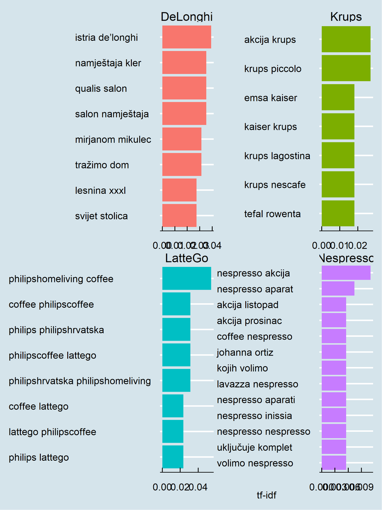

- Korelacija između DeLonghi i pojmova dom i Bauhaus
- LatteGo jako vezan uz brand Phillips
- Nespresso fokusiran na kavu (kvaliteta, priprema, stil)

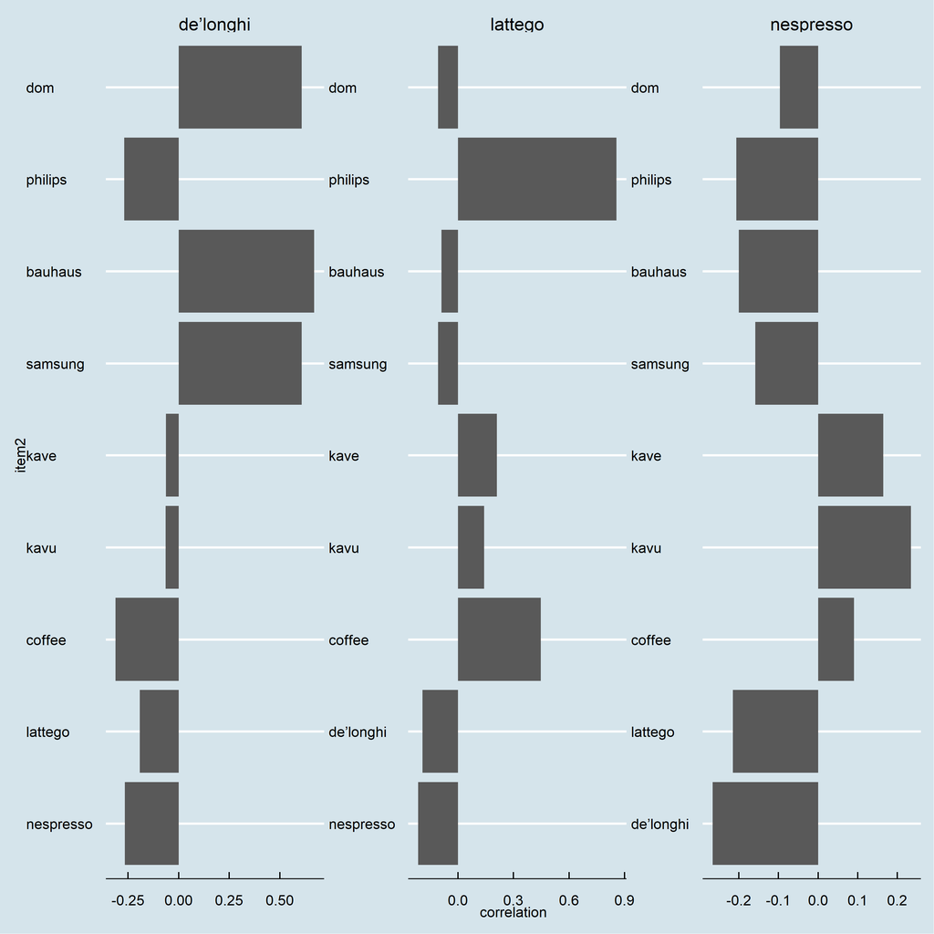

## **Tematska analiza**

- Identificirane **četiri teme**
- Jedna tema se odnosi na uređaje, karakteristike i brandove (tehnički aspekt)
- Druga tema je dom, opremanje doma i udobnost življenja
- Treća tema je okus i užitak pijenja kave
- Četvta tema tema su ponude, akcije, konkurencija

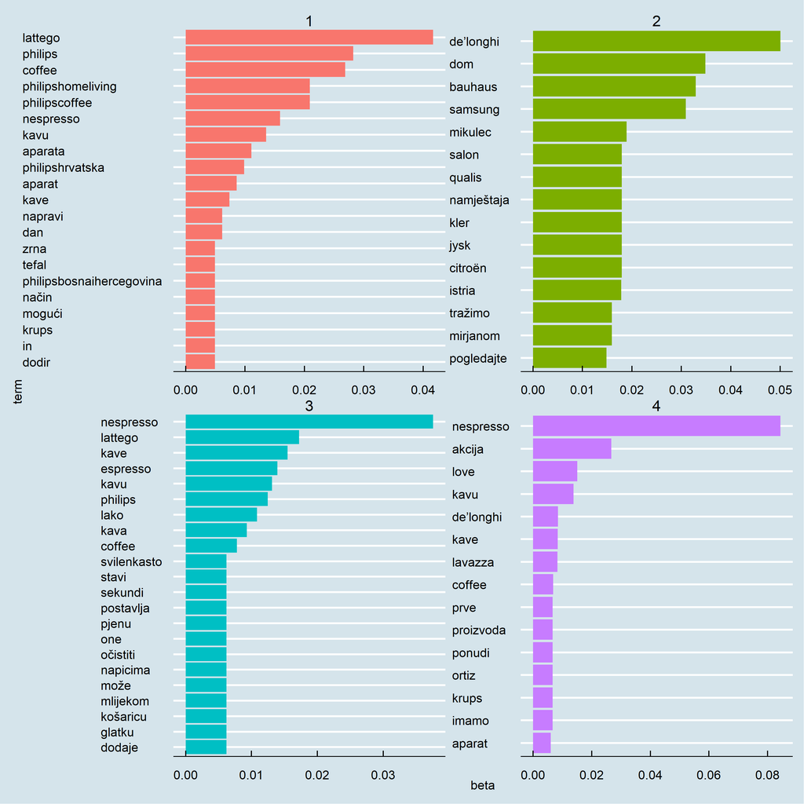

- Slični rezultati i na tematskoj analizi fraza
- Phillips se izdvaja kao zasebna tema

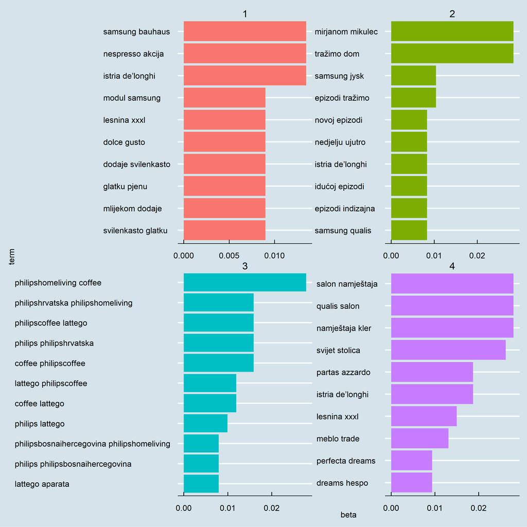

## **Zaključak**

- Web najbitniji medij
- Dijeljenje originalnog web sadržaja na mrežama
- Nespresso tržišni lider ali DeLonghi bolje pozicioniran u objavma

> *Mitologija doma* bolje prolazi kod domaće publike (DeLonghi)

> *Mitologija okusa i stila* manje populrna kod domaće publike (Nespresso)
- Važne teme: tehnički aspekti, opremanje doma, užitak konzumacije i okus, akcije i ponuda

Izradio lusiki

*Data from Mediatoolkit*